# Intro R Practice Problems - Week 2

Dr. Dani Kirsch & Dr. Jaina Agan

2026-08-10

## Dataset Description

For this week’s optional practice problems, we have provided another dataset for you to use.

`midwest` is a dataset that’s available in R as part of the `ggplot2` pacakge, similar to the `complete_old` dataset we have been using from the `ratdat` package. The `midwest` dataset has demographic information for counties from several Midwest states from the 2000 U.S. Census.

1. Write and execute the following code to read about where the dataset came from and what the variables are.

```r
?midwest
```

2. Use `str` to learn more about data types in the `midwest` dataset. Of the primary vector types we discussed in this week’s workshop (character, integer, numeric, logical), which are represented in this dataset?

## Make a Fancy Boxplot

Create a graph from the `midwest` data that compares population density between states. Follow the instructions below:

1. Compare `state` on the x-axis to `popdensity` on the y-axis.
2. Create a combined boxplot and scatter plot graph with the following features:
   - Use `geom_jitter` to create the scatter plot layer.
     - Set the color of the scatter plot data points to vary by the variable `state`.
     - Choose a new point shape (`shape =`). Shape is identified using integers, and these are some of your point shape options:

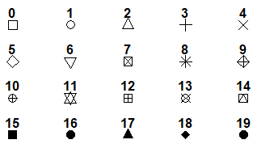

     - Set a transparency level.
     - Make the point size larger (`size =`).
   - Use `geom_boxplot` to create the boxplot layer.
     - Remove the `fill` color.
     - Remove the `outlier.shape` to avoid double-plotting outliers.
3. Set a new theme (e.g., `theme_classic()`, `theme_bw()`)
4. Change the labels so that:
   - Plot title is “Midwest Population Demographics (2000)”.
   - X-axis is “State”.
   - Y-axis is “Population Density (person/unit area)”.
5. Change other plot features using the `theme` function so that:
   - The size of the plot title text is 16 and the text face is **bold**.
   - The position of the legend is “none” (removes legend).

The graph you create should look similar to the following graph:

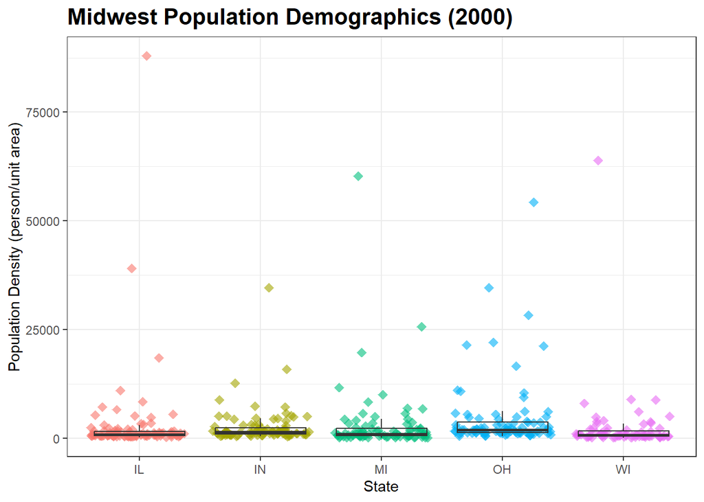

## Summary Statistics

Compute the following calculations on the `midwest` dataset:

1. What is the minimum value of population density (`popdensity`)?

```
## [1] 85.05
```

2. What is the maximum value of total population (`poptotal`)?  
   **Hint**: Use the function `max()`

```
## [1] 5105067
```

3. What are the quantiles (25%, 50%, 75%) for the percent of a county’s population that is college educated (`percollege`)?

```
##      25%      50%      75%
## 14.11372 16.79756 20.54989
```

4. What is the average number of adults per county (`popadults`)?  
   **Hint**: Use the function `mean()`

```
## [1] 60972.61
```

## Sequences

1. Create a sequence that runs from 8 to 85 at intervals of 7. Store this sequence as an object called `weird_seq`.

```
##  [1]  8 15 22 29 36 43 50 57 64 71 78 85
```

2. Create a sequence that runs from 1900 to 2025 at intervals of 5. Store this sequence as an object called `year_seq`.

```
##  [1] 1900 1905 1910 1915 1920 1925 1930 1935 1940 1945 1950 1955 1960 1965 1970
## [16] 1975 1980 1985 1990 1995 2000 2005 2010 2015 2020 2025
```

3. Create a sequence that is runs from 12 to 22 and has a length of 47 (47 total items in the sequence). Store this sequence as an object called `seq_length`.

```
##  [1] 12.00000 12.21739 12.43478 12.65217 12.86957 13.08696 13.30435 13.52174
##  [9] 13.73913 13.95652 14.17391 14.39130 14.60870 14.82609 15.04348 15.26087
## [17] 15.47826 15.69565 15.91304 16.13043 16.34783 16.56522 16.78261 17.00000
## [25] 17.21739 17.43478 17.65217 17.86957 18.08696 18.30435 18.52174 18.73913
## [33] 18.95652 19.17391 19.39130 19.60870 19.82609 20.04348 20.26087 20.47826
## [41] 20.69565 20.91304 21.13043 21.34783 21.56522 21.78261 22.00000
```

## Reflections

1. What was the most challenging aspect of this week’s workshop? Were you able to overcome it? If not, what assistance do you need to continue working through it?
2. What was the most rewarding aspect of this week’s workshop?

## Microcredential Activity Submission

> Submit your Week 2 R script file and your reflections to Dr. Jaina Agan (jagan@uco.edu) or Dr. Dani Kirsch (danielle.kirsch@okstate.edu)